# PROJECT 01: Spatial Distribution of Fire Incidents in D.C., Maryland, and Virginia in 2018

## 3.2.7 Fire incidence by cause and state

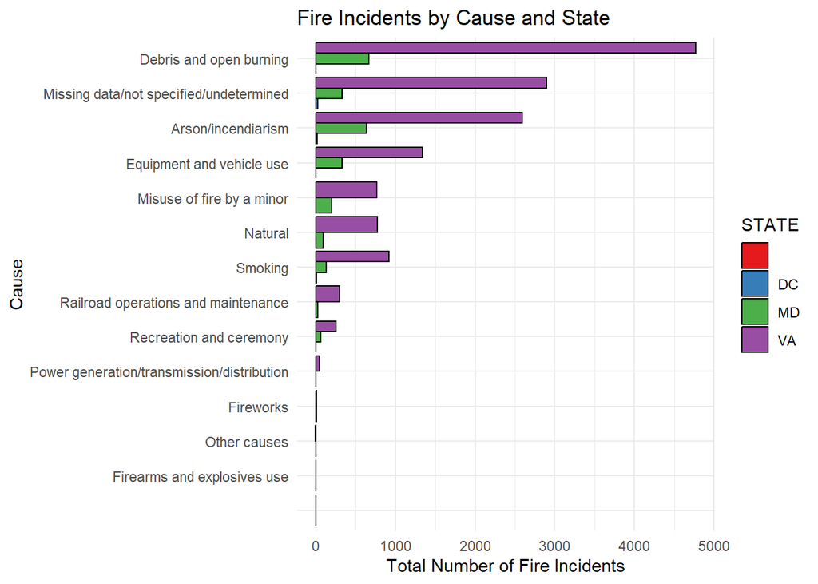

```r
# Load necessary libraries
library(dplyr)
library(ggplot2)

# Load the fire incidence CSV file
#fire_data_path <- "C:/Users/SIMBAH/Desktop/Intro to Data science/Project/Fire incidences DC_VA_MD_cleaned.csv"  # Update with your actual path
#fire_data <- read.csv(fire_data_path)

# Create a summary of total incidents by cause and state
cause_summary <- fire_data %>%
  group_by(STATE, NWCG_GENERAL_CAUSE) %>%
  summarise(total_incidents = n(), .groups = 'drop')  # Count incidents

# Visualize the data using a bar plot
ggplot(cause_summary, aes(x = reorder(NWCG_GENERAL_CAUSE, total_incidents), y = total_incidents, fill = STATE)) +
  geom_bar(stat = "identity", position = "dodge", color = "black") +  # Use position = "dodge" to separate bars by state
  coord_flip() +
  theme_minimal() +
  ggtitle("Fire Incidents by Cause and State") +
  xlab("Cause") +
  ylab("Total Number of Fire Incidents") +
  scale_fill_brewer(palette = "Set1")  # Optional: Use a color palette for better distinction
```

## 3.2.8 Fire Incidences by Ownership

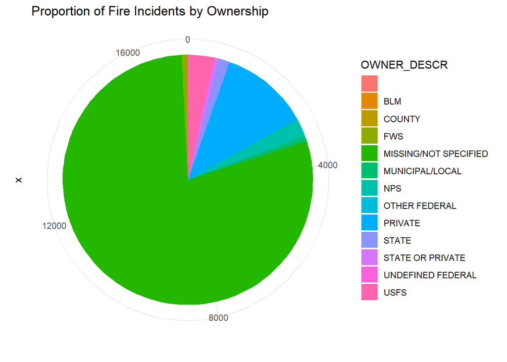

```r
ownership_summary <- fire_data %>%
  group_by(OWNER_DESCR) %>%
  summarise(total_incidents = n())

ggplot(ownership_summary, aes(x = "", y = total_incidents, fill = OWNER_DESCR)) +
  geom_bar(width = 1, stat = "identity") +
  coord_polar("y") +
  theme_minimal() +
  ggtitle("Proportion of Fire Incidents by Ownership") +
  ylab("")
```

# 3.2.9 Average fire size by cause

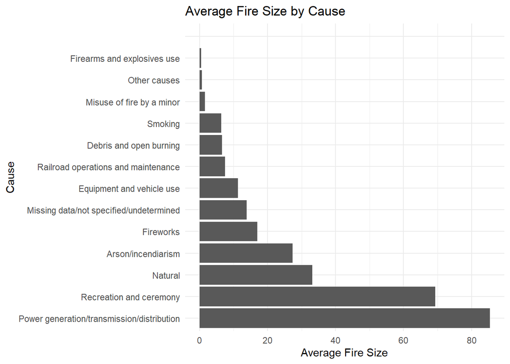

```r
# Load necessary libraries
library(tidyverse)
library(ggplot2)

# Load the dataset
fire_data <- read.csv("C:/Users/SIMBAH/Desktop/Intro to Data science/Project/Fire incidences DC_VA_MD_cleaned.csv")

# Sample code to create a basic map using ggplot2
# Average fire size by cause
size_analysis <- fire_data %>%
  group_by(NWCG_GENERAL_CAUSE) %>%
  summarise(avg_fire_size = mean(FIRE_SIZE, na.rm = TRUE),
            avg_cont_time = mean(CONT_TIME, na.rm = TRUE))

# Plotting
ggplot(size_analysis, aes(x = reorder(NWCG_GENERAL_CAUSE, -avg_fire_size), y = avg_fire_size)) +
  geom_bar(stat = "identity") +
  coord_flip() +
  labs(title = "Average Fire Size by Cause", x = "Cause", y = "Average Fire Size") +
  theme_minimal()
```

## 3.2.10 Geographic Distribution of Fire Incidences by cause

```r
# Load necessary libraries
library(sf)
library(ggplot2)
library(dplyr)

# Load the fire incidence CSV file
fire_data_path <- "C:/Users/SIMBAH/Desktop/Intro to Data science/Project/Fire incidences DC_VA_MD_cleaned.csv"  # Update with your actual path
fire_data <- read.csv(fire_data_path)

# Check for missing values in LONGITUDE and LATITUDE
missing_coords <- fire_data %>%
  filter(is.na(LONGITUDE) | is.na(LATITUDE))

# Print missing coordinates
if (nrow(missing_coords) > 0) {
  print("Rows with missing coordinates:")
  print(missing_coords)
}
```

```
## [1] "Rows with missing coordinates:"
##   OBJECTID SOURCE_SYSTEM_TYPE SOURCE_SYSTEM NWCG_REPORTING_UNIT_NAME
## 1       NA
##   SOURCE_REPORTING_UNIT_NAME FIRE_YEAR Month NWCG_CAUSE_CLASSIFICATION
## 1                                   NA
##   NWCG_GENERAL_CAUSE NWCG_CAUSE_AGE_CATEGORY CONT_TIME FIRE_SIZE
## 1                                                   NA        NA
##   FIRE_SIZE_CLASS LATITUDE LONGITUDE OWNER_DESCR STATE FIPS_NAME
## 1                       NA        NA
```

```r
# Remove rows with missing coordinates
fire_data_clean <- fire_data %>%
  filter(!is.na(LONGITUDE) & !is.na(LATITUDE))

# Load the shapefile
shapefile_path <- "C:/Users/SIMBAH/Desktop/Intro to Data science/Project/DC_MD_VA Boundaries/Project_Area.shp"  # Update this path to your shapefile
states_shapefile <- st_read(shapefile_path)
```

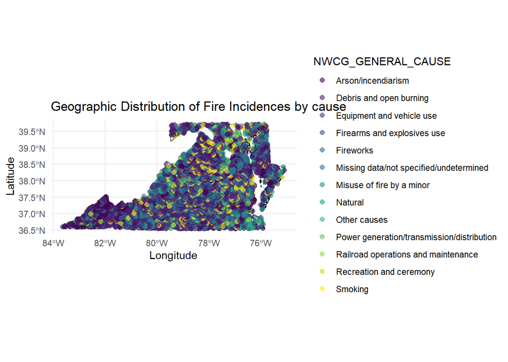

```r
# Convert fire data to sf object (for plotting)
fire_data_sf <- st_as_sf(fire_data_clean, coords = c("LONGITUDE", "LATITUDE"), crs = 4326)

# Create a geographic map with shapefile and fire incidents
ggplot() +
  geom_sf(data = states_shapefile, fill = NA, color = "black") +  # Plot shapefile
  geom_sf(data = fire_data_sf, aes(color = NWCG_GENERAL_CAUSE), alpha = 0.6, size = 2) +  # Plot fire incidents
  scale_color_viridis_d() +  # Optional: Use a color palette for causes
  theme_minimal() +
  ggtitle("Geographic Distribution of Fire Incidences by cause") +
  xlab("Longitude") +
  ylab("Latitude")
```

## 3.2.11 Confidence Intervals

```r
# Load necessary libraries
library(dplyr)

# Load the fire incidence CSV file
fire_data_path <- "C:/Users/SIMBAH/Desktop/Intro to Data science/Project/Fire incidences DC_VA_MD_cleaned.csv"  # Update with your actual path
fire_data <- read.csv(fire_data_path)

# Summarize the data to get counts of incidents by state and cause
incident_counts <- fire_data %>%
  group_by(STATE, NWCG_GENERAL_CAUSE) %>%
  summarise(Incident_Count = n(), .groups = 'drop')

# 1. ANOVA: Testing for differences in means across states based on cause
anova_result <- aov(Incident_Count ~ STATE, data = incident_counts)  # Adjust column names as necessary
anova_summary <- summary(anova_result)

# Print ANOVA summary for debugging
print(anova_summary)
```

```
##             Df   Sum Sq Mean Sq F value Pr(>F)
## STATE        3  7576273 2525424    2.64   0.07 .
## Residuals   27 25831866  956736
## ---
## Signif. codes:  0 '***' 0.001 '**' 0.01 '*' 0.05 '.' 0.1 ' ' 1
```

```r
# Check if ANOVA summary has results
if (length(anova_summary) > 0 && !is.null(anova_summary[[1]])) {
  # Check if p-value is significant
  if (anova_summary[[1]][["Pr(>F)"]][1] < 0.05) {
    tukey_result <- TukeyHSD(anova_result)  # Perform Tukey's HSD test for pairwise comparisons
    print(tukey_result)
  } else {
    print("No significant differences found in ANOVA.")
  }
} else {
  print("ANOVA did not produce valid results.")
}
```

```
## [1] "No significant differences found in ANOVA."
```

```r
# 2. t-test: Compare Virginia (VA) and Maryland (MD) means
va_incidents <- incident_counts %>% filter(STATE == "VA")  # Using STATE for Virginia
md_incidents <- incident_counts %>% filter(STATE == "MD")  # Using STATE for Maryland

# Ensure there are enough observations
if (nrow(va_incidents) > 0 && nrow(md_incidents) > 0) {
  t_test_result <- t.test(va_incidents$Incident_Count, md_incidents$Incident_Count, var.equal = TRUE)  # Adjust as necessary
  print(t_test_result)
} else {
  print("Not enough data for t-test.")
}
```

```
##
##  Two Sample t-test
##
## data:  va_incidents$Incident_Count and md_incidents$Incident_Count
## t = 2, df = 22, p-value = 0.05
## alternative hypothesis: true difference in means is not equal to 0
## 95 percent confidence interval:
##   -16.7 1824.6
## sample estimates:
## mean of x mean of y
##      1129       225
```

```r
# 3. Confidence Interval for Virginia's mean
if (nrow(va_incidents) > 0) {
  mean_va <- mean(va_incidents$Incident_Count, na.rm = TRUE)
  std_error_va <- sd(va_incidents$Incident_Count, na.rm = TRUE) / sqrt(nrow(va_incidents))

  # 95% Confidence Interval
  error_margin <- qt(0.975, df = nrow(va_incidents) - 1) * std_error_va
  ci_va <- c(mean_va - error_margin, mean_va + error_margin)
  print(paste("95% Confidence Interval for Virginia's mean:", ci_va[1], "to", ci_va[2]))
} else {
  print("No data available for Virginia.")
}
```

```
## [1] "95% Confidence Interval for Virginia's mean: 252.089641767216 to 2005.2949736174"
```

## 3.2.12 Analysis of Variance (ANOVA)

```r
# 1. ANOVA: Testing for differences in means across states based on cause
anova_result <- aov(Incident_Count ~ STATE, data = incident_counts)  # Adjust column names as necessary
anova_summary <- summary(anova_result)

# Print ANOVA summary for debugging
print(anova_summary)
```

```
##             Df   Sum Sq Mean Sq F value Pr(>F)
## STATE        3  7576273 2525424    2.64   0.07 .
## Residuals   27 25831866  956736
## ---
## Signif. codes:  0 '***' 0.001 '**' 0.01 '*' 0.05 '.' 0.1 ' ' 1
```

```r
# Check if ANOVA summary has results
if (length(anova_summary) > 0 && !is.null(anova_summary)) {
  # Check if p-value is significant
  if (anova_summary[[1]][["Pr(>F)"]][1] < 0.05) {
    tukey_result <- TukeyHSD(anova_result)  # Perform Tukey's HSD test for pairwise comparisons
    print(tukey_result)
  } else {
    print("No significant differences found in ANOVA.")
  }
} else {
  print("ANOVA did not produce valid results.")
}
```

```
## [1] "No significant differences found in ANOVA."
```

# 3.3 Objective 3: Investigate Environmental Factors Influencing Fire Incidences

## 3.3.1 Data Integration

The code below is eval=FALSE since raw data(Wildfire Dataset(from Kaggle)) it’s too big and can’t be uploaded on Github.

```r
# Read CSV
clean_df = '/Users/jeongwonyoo/Documents/GitHub/introds-project1/Fire incidences DC_VA_MD_cleaned.csv'
raw_df = '/Users/jeongwonyoo/Documents/GitHub/introds-project1/Wildfire_Dataset.csv'

library('readr')
clean_df = read_csv(clean_df)
raw_df = read_csv(raw_df)

# Make row_df columns names same as clean_df
names(raw_df) = toupper(names(raw_df))

# Add State name on raw data
options(tigris_use_cache = TRUE)

states = tigris::states(cb = TRUE, year = 2023) %>%
    st_transform(4326) %>%
    select(STUSPS, NAME, geometry)

sf_raw = st_as_sf(raw_df %>% filter(!is.na(LATITUDE), !is.na(LONGITUDE)),coords = c("LONGITUDE","LATITUDE"), crs = 4326, remove=FALSE)

raw_with_state_poly = st_join(sf_raw, states, join = st_within) %>%
    st_drop_geometry() %>%
    rename(STATE = STUSPS)

# sort target data(state(VA,DC,MD),time(2018))
target_states = c("DC","MD","VA")
target_year = 2018
cols_keep = c("STATE","FIRE_YEAR","Month","LATITUDE","LONGITUDE",
                   "DATETIME","PR","RMAX","RMIN","SPH","SRAD","TMMN",
                  "TMMX","VS","BI","FM100","FM1000","ERC","ETR","PET","VPD")

# Make sub dataset of clean_df
clean_sub = clean_df %>%
    filter(STATE %in% target_states,
           FIRE_YEAR == target_year) %>%
    select(any_of(cols_keep))

# Make sub dataset of raw_df
raw_sub = raw_with_state_poly %>%
    filter(STATE %in% target_states,
           lubridate::year(lubridate::as_datetime(DATETIME)) == target_year) %>%
    drop_na(LATITUDE, LONGITUDE) %>%
    select(any_of(cols_keep))

# organized data check
str('raw_sub')
```

Call new dataset for the analysis

```r
dp = 'clean_object2_2018_DCMDVA.csv'
object2 = read_csv(dp)
```

Here is a table description for the object3 dataset

```r
library(dplyr)
library(knitr)

vars <- tibble::tribble(
  ~Variable,      ~Description,                                   ~Units,
  "PR",           "Precipitation",                                 "mm/day",
  "RMAX / RMIN",  "Relative humidity (Maximum / Minimum)",         "%",
  "SPH",          "Specific humidity",                             "kg/kg",
  "SRAD",         "Solar radiation",                               "W/m²",
  "TMMN / TMMX",  "Temperatures (Minimum / Maximum)",              "°C",
  "VS",           "Wind speed",                                    "m/s",
  "VPD",          "Vapor pressure deficit",                        "kPa",
  "FM100 / FM1000","Fuel moisture indices",                        "%",
  "ERC",          "Energy Release Component",                      "index",
  "BI",           "Burning Index",                                 "index",
  "ETR / PET",    "Evapotranspiration (ETR) / Potential (PET)",    "mm/day"
)

knitr::kable(
  vars,
  format = "html",
  caption = "Variable definitions used in the analysis",
  align = c("l","l","c")
)
```

Variable definitions used in the analysis

| Variable | Description | Units |
| --- | --- | --- |
| PR | Precipitation | mm/day |
| RMAX / RMIN | Relative humidity (Maximum / Minimum) | % |
| SPH | Specific humidity | kg/kg |
| SRAD | Solar radiation | W/m² |
| TMMN / TMMX | Temperatures (Minimum / Maximum) | °C |
| VS | Wind speed | m/s |
| VPD | Vapor pressure deficit | kPa |
| FM100 / FM1000 | Fuel moisture indices | % |
| ERC | Energy Release Component | index |
| BI | Burning Index | index |
| ETR / PET | Evapotranspiration (ETR) / Potential (PET) | mm/day |

## 3.3.2 Correlation Analysis

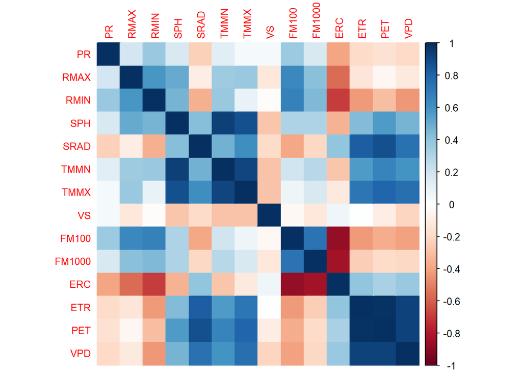

```r
env_vars = object2 %>% select(PR, RMAX, RMIN, SPH, SRAD, TMMN, TMMX, VS, FM100, FM1000, ERC, ETR, PET, VPD)
cor_mat = cor(env_vars, use = "complete.obs")
corrplot(cor_mat, method = "color", tl.cex = 0.8)
```

Correlation heatmap

## 3.3.3 Raster Maps

- Raster maps visualize spatial distribution of environmental variables and their relation to fire potential
- Each pixel represents mean value of variable within geographic grid

```r
library(dplyr); library(ggplot2)

plot_raster <- function(df, var, bins = 60, to_celsius = FALSE) {
    z <- if (to_celsius) df[[var]] - 273.15 else df[[var]]
    ggplot(df, aes(LONGITUDE, LATITUDE, z = z)) +
        stat_summary_2d(fun = mean, bins = bins, na.rm = TRUE) +
        coord_fixed(expand = FALSE) +
        scale_fill_viridis_c(name = var) +
        labs(title = paste(var, "Distribution")) +
        theme_minimal(base_size = 12)
}
```

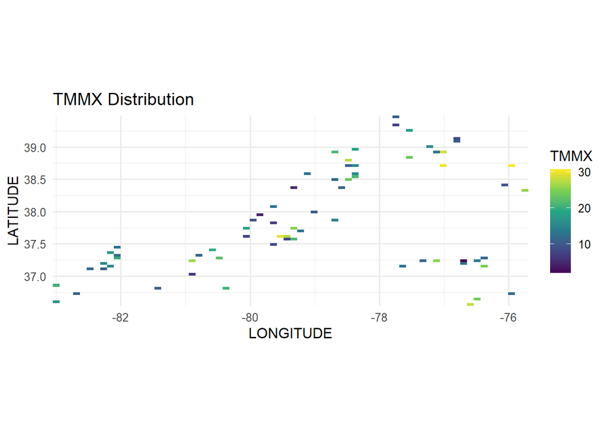

```r
plot_raster(object2, "TMMX", bins = 70, to_celsius = TRUE)
```

TMMX(Maximum Temperatures) binned raster map

- higher in central–eastern areas, lower in west, overlaps with higher VPD zones

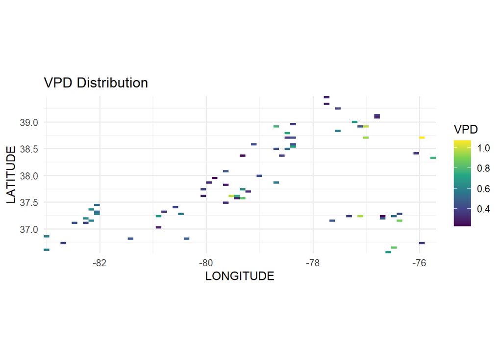

```r
plot_raster(object2, "VPD",  bins = 70)
```

VPD(Vapor presure deficit) binned raster map

- high-dryness pockets in warm central/eastern areas, primary dryness proxy recommended to avoid collinearity with TMMX

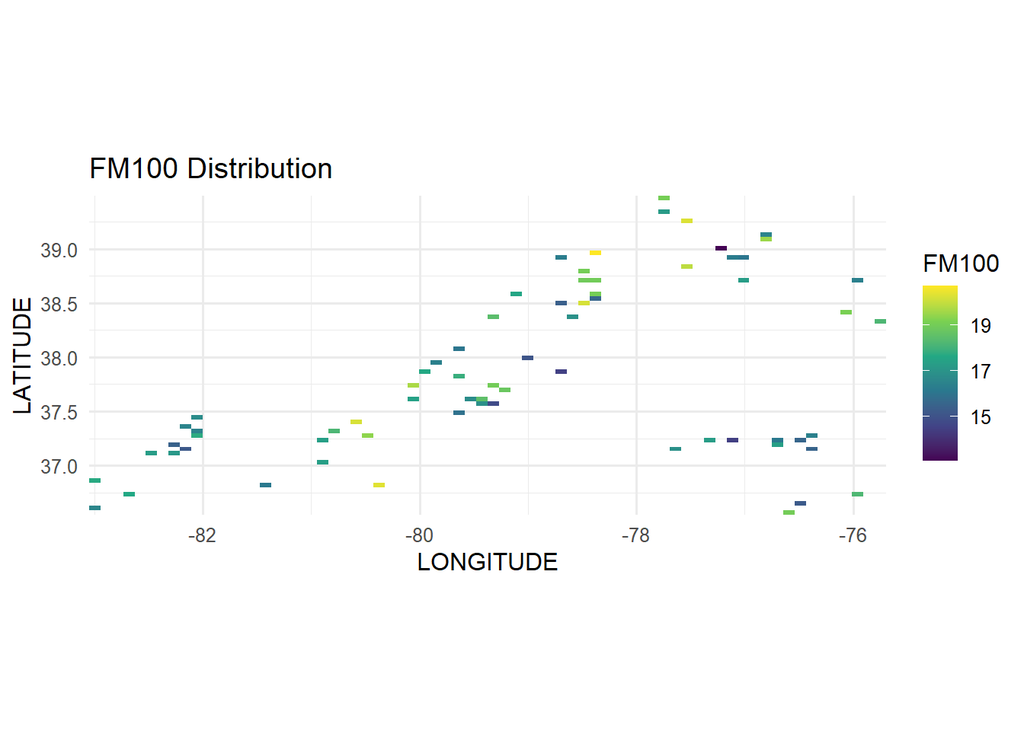

```r
plot_raster(object2, "FM100", bins = 70)
```

FM100(Fuel Moisture indices) binned raster map

- wetter fuels (higher FM100) in central–north/east
- drier (lower FM100) in west/southwest → higher fire potential where low FM100 coincides with high VPD

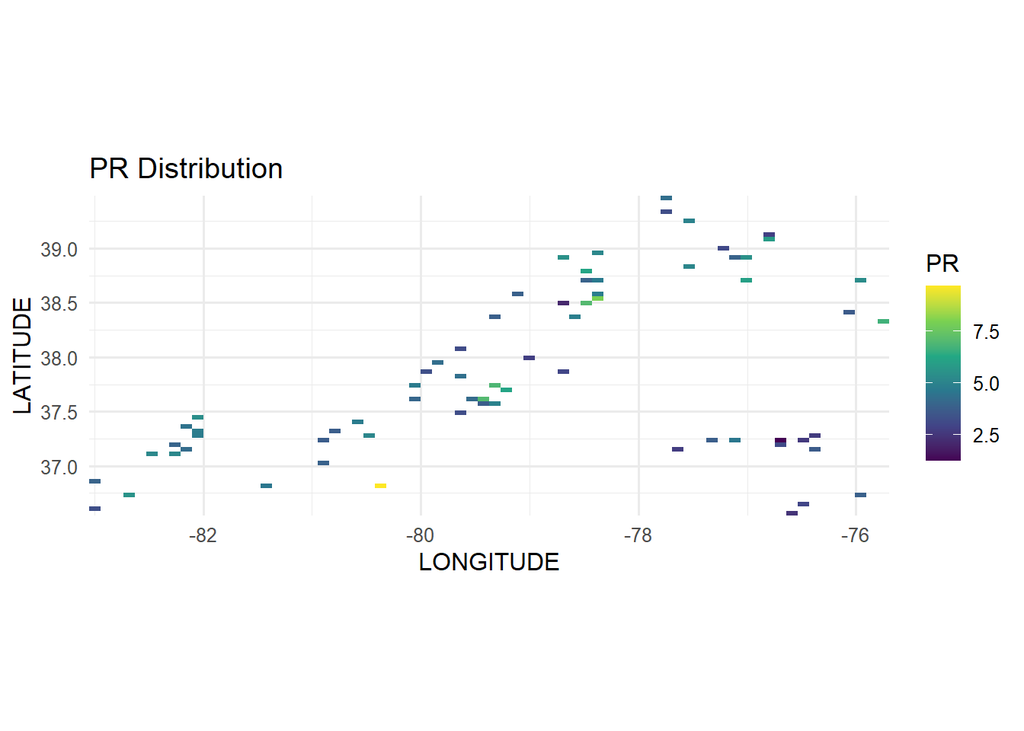

```r
plot_raster(object2, "PR",   bins = 70)
```

PR(precipitation) binned raster map

- patchy distribution
- higher PR corresponds to lower ERC, consistent with wetting effects

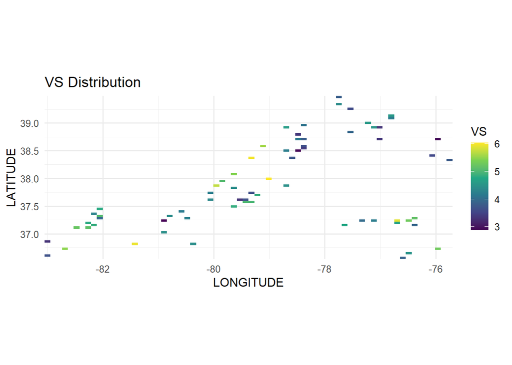

```r
plot_raster(object2, "VS",   bins = 70)
```

VS(Wind Speed) binned raster map

- localized maxima not always aligned with high ERC zones → wind acts as short-term enhancer, not persistent driver

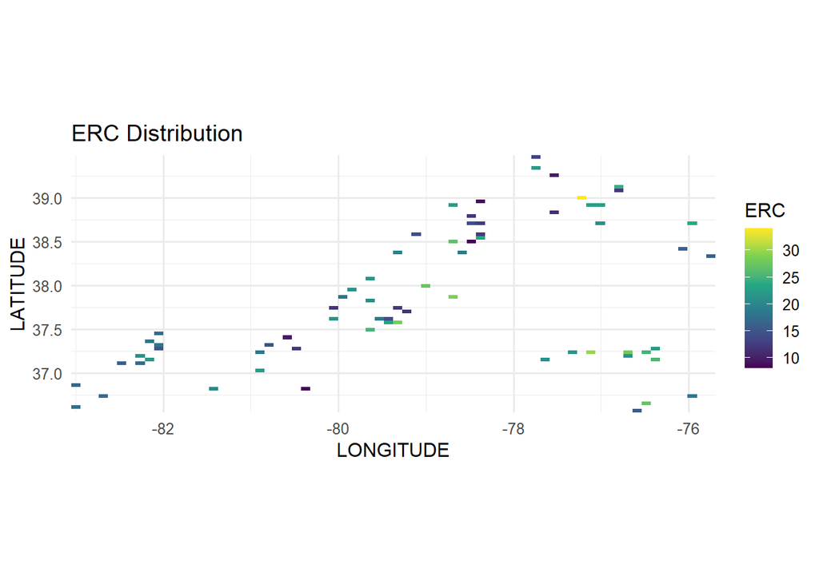

```r
plot_raster(object2, "ERC",  bins = 70)
```

ERC(Energy release component) binned raster map

## 3.3.4 Scatter Plots

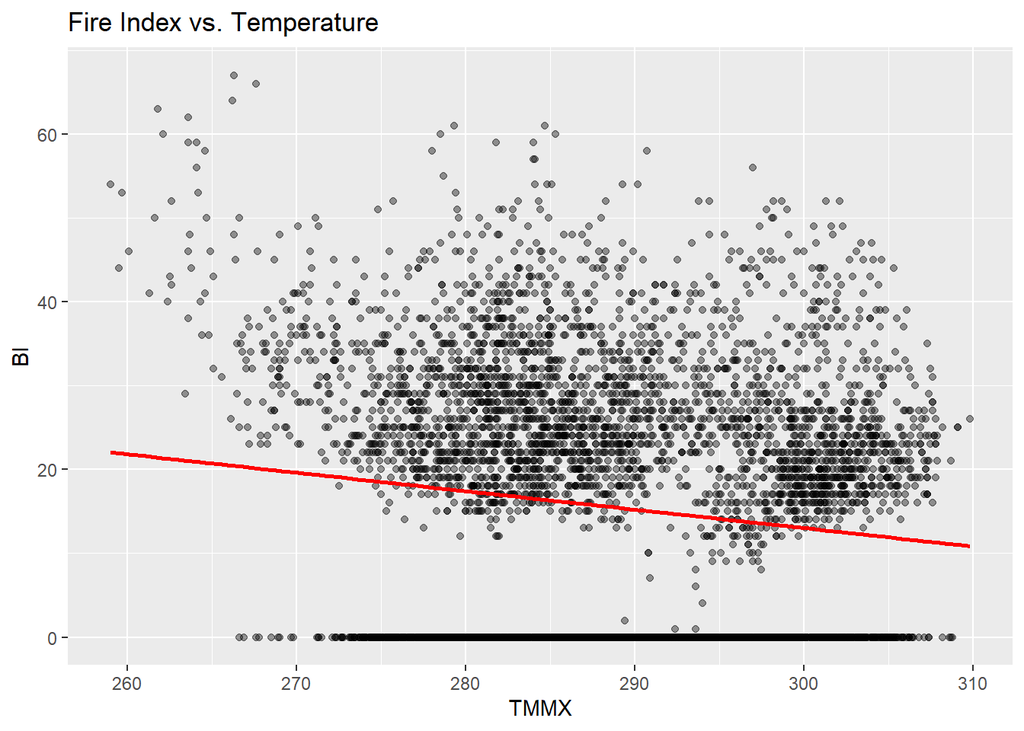

```r
ggplot(object2, aes(x = TMMX, y = BI)) +geom_point(alpha = 0.4)+     geom_smooth(method = "lm", se = FALSE, color = "red")+labs(title = "Fire Index vs. Temperature")
```

BI(Burning index) vs. TMMX

## 3.3.5 Regression Diagnostics Plots

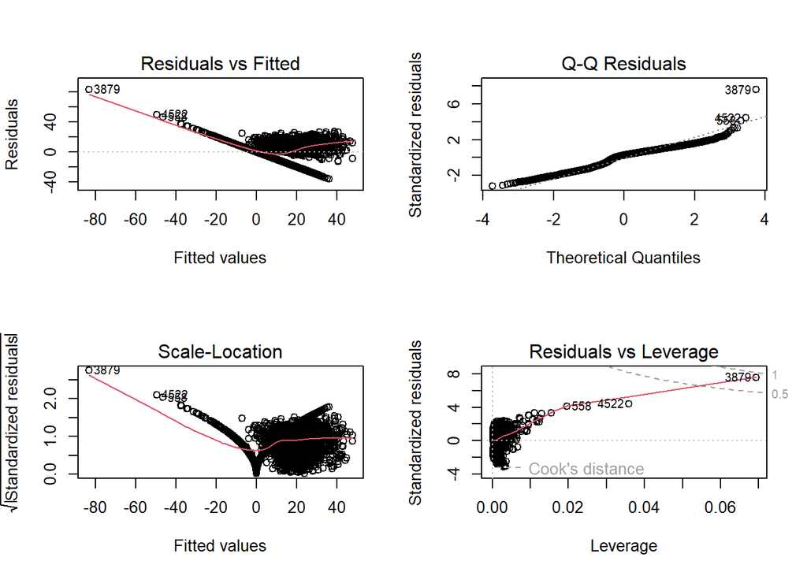

```r
model = lm(BI ~ TMMX + PR + VS + VPD, data = object2)
par(mfrow = c(2, 2))
plot(model)
```

- Residuals vs Fitted: fan-shaped and curved → heteroscedasticity and nonlinearity
- Q–Q Plot: heavy tails → outliers and non-normal residuals
- Scale–Location Plot: confirms nonconstant variance
- Residuals vs Leverage: presence of high-leverage points → potential influence on coefficient stability
- OLS assumptions violated → spatial or robust models recommended

## 3.3.6 Spatial Regression

The code chunk is taking long-running: disabled during knit (works in Console). Keep full code here for reproducibility and results pasted below.

```r
o2 = object2 %>%
  group_by(LONGITUDE, LATITUDE) %>%
  summarise(across(c(PR, RMAX, RMIN, SPH, SRAD, TMMN, TMMX, VS,
                     FM100, FM1000, ERC, ETR, PET, VPD),
                   ~mean(.x, na.rm = TRUE)), .groups = "drop") %>%
  mutate(id = row_number())

vars = c("ERC","TMMX","VPD","FM100","PR","VS","RMAX","SRAD")

keep_logical = complete.cases(o2[, vars])

dat = o2[keep_logical, c(vars, "id"), drop = FALSE]
stopifnot(nrow(dat) > 1)

coords = as.matrix(o2[, c("LONGITUDE","LATITUDE")])
coords_k = coords[dat$id, , drop = FALSE]
stopifnot(nrow(coords_k) == nrow(dat))

k = 8
repeat {
  nb = knn2nb(knearneigh(coords_k, k = k, longlat = TRUE))
  if (n.comp.nb(nb)$nc == 1 || k >= 20) break
  k = k + 2
}

lw_k = nb2listw(nb, style = "W", zero.policy = FALSE)

xvars = c("TMMX","VPD","FM100","PR","VS","RMAX","SRAD")
dat_std = dat
dat_std[xvars] = scale(dat_std[xvars])

ols = lm(ERC ~ TMMX + VPD + FM100 + PR + VS + RMAX + SRAD, data = dat_std)
sem = errorsarlm(ERC ~ TMMX + VPD + FM100 + PR + VS + RMAX + SRAD,
                  data = dat_std, listw = lw_k, na.action = na.exclude)

summary(ols)
summary(sem)
moran.test(residuals(ols), lw_k)
moran.test(residuals(sem), lw_k)
```

# 3.3.7 Description of Results

- summary(ols)

Call: lm(formula = ERC ~ TMMX + VPD + FM100 + PR + VS + RMAX + SRAD, data = dat_std)

Residuals: Min 1Q Median 3Q Max -4.7305 -1.2031 0.2945 1.4940 3.0632

Coefficients: Estimate Std. Error t value Pr(>|t|)  
(Intercept) 19.0706 0.2347 81.252 < 2e-16 TMMX -1.5034 1.3189 -1.140 0.258491  
VPD 1.0727 1.2690 0.845 0.401050  
FM100 -4.8261 1.1851 -4.072 0.000129 PR -1.0014 0.3540 -2.829 0.006203 ** VS -0.2254 0.3353 -0.672 0.503884  
RMAX 0.1135 0.8120 0.140 0.889270  
SRAD 0.2321 0.7866 0.295 0.768867  
— Signif. codes: 0 ’’ 0.001 ’’ 0.01 ’’ 0.05 ‘.’ 0.1 ‘ ’ 1

Residual standard error: 2.005 on 65 degrees of freedom Multiple R-squared: 0.9028, Adjusted R-squared: 0.8924 F-statistic: 86.28 on 7 and 65 DF, p-value: < 2.2e-16

- summary(sem)

Call:errorsarlm(formula = ERC ~ TMMX + VPD + FM100 + PR + VS + RMAX + SRAD, data = dat_std, listw = lw_k, na.action = na.exclude)

Residuals: Min 1Q Median 3Q Max -4.00770 -1.09347 0.12968 1.09124 2.98286

Type: error Coefficients: (asymptotic standard errors) Estimate Std. Error z value Pr(>|z|) (Intercept) 19.12921 0.60304 31.7211 < 2.2e-16 TMMX -2.10797 0.88425 -2.3839 0.01713 VPD 2.08839 0.91643 2.2788 0.02268 FM100 -4.32810 0.81694 -5.2979 1.171e-07 PR -0.56119 0.24728 -2.2694 0.02324 VS -0.23018 0.26144 -0.8804 0.37863 RMAX -0.50397 0.56725 -0.8884 0.37430 SRAD -0.11324 0.57086 -0.1984 0.84277

Lambda: 0.72518, LR test value: 36.149, p-value: 1.8279e-09 Asymptotic standard error: 0.082947 z-value: 8.7427, p-value: < 2.22e-16 Wald statistic: 76.435, p-value: < 2.22e-16

Log likelihood: -132.0661 for error model ML residual variance (sigma squared): 1.9885, (sigma: 1.4101) Number of observations: 73 Number of parameters estimated: 10 AIC: 284.13, (AIC for lm: 318.28)

- moran.test(residuals(ols), lw_k)

  Moran I test under randomisation

data: residuals(ols)  
weights: lw_k

Moran I statistic standard deviate = 9.0678, p-value < 2.2e-16 alternative hypothesis: greater sample estimates: Moran I statistic Expectation Variance 0.450965435 -0.013888889 0.002628031

- moran.test(residuals(sem), lw_k)

  Moran I test under randomisation

data: residuals(sem)  
weights: lw_k

Moran I statistic standard deviate = -0.12209, p-value = 0.5486 alternative hypothesis: greater sample estimates: Moran I statistic Expectation Variance -0.020133928 -0.013888889 0.002616504

### 3.3.8 Result Description

- OLS Model: significant negative effects from FM100 and PR; other predictors less significant, residual diagnostics indicate heteroscedasticity and spatial clustering
- SEM Model: improved fit (AIC 284.13 vs 318.28); strong spatial dependence (λ = 0.725, p < 0.001)
- Model comparison: SEM preferred → captures spatial error structure and improves fit Dryness and moisture as key drivers: high VPD and low FM100 elevate fire potential, precipitation reduces it
- Temperature vs VPD: VPD better represents combined heat-dryness effect; reduces multicollinearity and sign reversal
- Residual patterns: SEM removes spatial clustering and produces stable estimates
- Overall finding: spatial error modeling confirms that dry atmosphere, low fuel moisture, and limited rainfall are dominant environmental controls on fire energy release in DC–MD–VA regions.

## Chapter 4: Conclusion and Recommendations

## 4.1 Conclusion

Final Integrated Conclusion

1. Comprehensive Relationship between Fire Incidents and Environmental Factors

Fire occurrences across Washington, D.C., Maryland, and Virginia in 2018 were not random events but rather the outcome of interacting geographic, climatic, and anthropogenic factors. Among all variables, Vapor Pressure Deficit (VPD), Fuel Moisture (FM100), and Precipitation (PR) emerged as the most critical predictors of fire potential. Drier air (higher VPD), lower fuel moisture, and limited rainfall jointly amplified the Energy Release Component (ERC), indicating greater fire intensity and risk.Conversely, high fuel moisture and increased precipitation significantly mitigated fire potential, confirming that dryness and wetness dynamics are the dominant controls on regional fire patterns.

# 4.2 Recommendations

Implement real time monitoring of dryness and moisture indicators to improve early detection. Prioritize targeted hotspot management in areas with elevated fire potential. Develop region specific prevention plans that reflect local environmental characteristics and historical fire behavior.

# REFERENCES

Fire Loss in the United States 2020

National Emergency Response Information System (NERIS) 2019

National Fire Incident Reporting System (NFIRS) 2018

National Fire Protection Association (NFPA) 2019

National Inter-agency Fire Center (NIFC) 2020

U.S. Fire Administration (USFA) 2018

USFA Topical Fire Reports 2018

NFPA Survey Estimates 2019